# R Notebook

Assume home team $i$ (listed at -130 on the money line) is playing away team $j$ (+110). Punters backing $i$ believe that squad has better than a $\frac{130}{230} = 56.5%$ chance of winning, while betters on team $j$ assume it has at least a $\frac{100}{210} = 47.6%$ probability of winning. Accounting for the vig – which markets use to ensure a long-term profit – team $i$ can be assumed to have a $54.3%$ chance of beating $j$.

```r
library(tidyverse)
library(rjags)
library(gsheet)
library(lubridate)
library(stringr)
library(knitr)

logit <- function(p) {
  out <- log(p/(1 - p))
  return(out)
}
```

| date | home | away | p_home |
| --- | --- | --- | --- |
| 2017-10-04 | Winnipeg Jets | Toronto Maple Leafs | 0.5284 |
| 2017-10-04 | Pittsburgh Penguins | St. Louis Blues | 0.6275 |
| 2017-10-04 | Edmonton Oilers | Calgary Flames | 0.5900 |
| 2017-10-04 | San Jose Sharks | Philadelphia Flyers | 0.5810 |

In the first four games of the year, Winnipeg, Pittsburgh, Edmonton, and San Jose were all favorites to some degree, with Pittsburgh the most plausible winner.

## Building a State Space Model

Let $y_{i,j,w} = \text{logit}(p_{i,j,w})$ (in our data, this is called `p_home`) be the log-odds of the observed betting market probability in a game played between $i$ and $j$ during week $w$. We take the `logit` transform of each probability, which more closely aligns our outcomes with a normal distribution.

We formally assume that:

$$\text{E}[\text{logit}(p_{i,j,w})] = \theta_{i,w} - \theta_{j,w} + \alpha,$$

where $\theta_{i,w}$ and $\theta_{j,w}$ reflect the corresponding team strengths of $i$ and $j$ during week $w$, and $\alpha$ is the home advantage parameter. You’ll note that as $\theta_{i,w}$ goes up, so to does team $i$’s probability of winning; followers of paired comparison comparison models will recognize this formulation as identical to Bradley-Terry.

A state-space model assumes that the team strength estimates ($\theta_{i,w}$, $\theta_{j,w}$, etc.) evolve over time, with team $i$’s strength at week $w$ a function of both how good it was last week ($\theta_{i,(w-1)}$), as well as some prior noise. This is perfect for sports data – teams generally evolve slowly, and the best predictor of how good any given team is at a given time point is likely closely related to how good it was at the time just prior.

Formally, we assume that for any given team $i$,

$$\theta_{i,w} \sim N(\gamma\theta_{i,(w-1)},\tau_w^2),$$

which imposes a first-order auto-regressive process to team strength (denoted by $\gamma$). Above, $\tau_w^2$ corresponds to week-level uncertainty in the evolution of team strength. In the long run, we assume $\gamma < 1$, which prevents team strengths from exploding, and corresponds to the fact that, eventually, the best and worst teams in pro-sports will revert towards the league average.

Here’s how we can built the model above, where we use the `rjags` package in R to do some Bayesian inference using Gibbs sampling. First, we define our model inputs using outcome $y$, week $w$, and design matrix $x$. For an $n$-game season played between $T$-number of teams, $x$ corresponds to an $n$ x $T$ matrix, where each row contains exactly one 1 (for the home team) and one -1 (for the away team).

```r
y <- logit(nhl1718$p_home)
w <- nhl1718$week

#create a design matrix
Teams <- sort(as.character(unique(c(as.character(nhl1718$home)))))

#Defining the number of things
nTeams <- length(Teams)
nWeeks <- max(nhl1718$week)
n <- nrow(nhl1718)

#Defining the design matrix
x <- matrix(0, nrow = dim(nhl1718)[1], ncol = length(Teams))
for (i in 1:dim(nhl1718)[1]) {
  x[i, which(as.character(nhl1718[i, "home"]) == Teams)] <- (1)
  x[i, which(as.character(nhl1718[i, "away"]) == Teams)] <- (-1)
}
```

As an example, row 1, a game between home team Winnipeg (the 31st NHL team, alphabetically) and away team Toronto (27th), has a `1` in the 31st column and a `-1` in the 27th column, with the rest of the entries equal to zero.

Next, our Bayesian approach requires prior distributions on the parameters of interest. I’m happy to answer specific questions if you’d like, but the BUGS code below corresponds to the models above, along with some additional variance parameters that use vague priors. The `rjags` package is a bit outdated, but here’s [one resource](http://www.jkarreth.net/files/bayes-cph_Tutorial-JAGS.pdf) where you can learn more.

Here’s what the BUGS code looks like:

```r
model.string <-"
  model {
for (i in 1:n) {
  y[i] ~ dnorm(mu[i], tauGame)
  mu[i] <- alpha + inprod(theta[w[i],],x[i,])
}
for (j in 1:nTeams){
  theta[1,j] ~ dnorm(0, tauSeason)
}
for (www in 2:nWeeks) {
  for (j in 1:nTeams) {
    theta[www,j] ~ dnorm(gammaWeek*theta[www-1,j], tauWeek)
  }
}
alpha ~ dnorm(0,0.0001)
tauGame ~ dunif(0,1000) #uncertainty in outcome for each game
tauWeek ~ dunif(0,1000)
tauSeason ~ dunif(0,1000) #variance parameter for the first week of the season
gammaWeek ~ dunif(0,1.5)
}
"
model.spec<-textConnection(model.string)
```

Now we’re ready to fit the model. In this example, I used 3 chains, 1000 posterior draws, and a thin of 5, which yields 3 sets of 200 draws for each parameter. The model converges quickly, otherwise we’d want to increase the number of draws at each step.

```r
library(rjags)

n.chains <- 3
n.adapt <- n.update <- n.draws <- 1000
posteriorDraws = c('alpha','theta')
thin <- 5
jags <- jags.model(model.spec,
                   data = list('y' = y,'x' = x, 'w' = w, 'n' = n,'nTeams' = nTeams,'nWeeks' = nWeeks),
                   n.chains = n.chains, n.adapt = n.adapt)
```

```r
update(jags, n.update)
```

[output not shown]

```r
z <- jags.samples(jags, posteriorDraws, n.draws, thin = thin)
```

[output not shown]

## Examining model output

```r
dim(z$alpha)
dim(z$theta)
```

It’s generally a good idea to start a Bayesian analysis by assessing convergence – we do this extensively in our [paper](https://arxiv.org/abs/1701.05976) – but here’s one trace plot of `alpha`, which shows that it’s generally well-behaved. Note the y-axis scale – given that our model uses log-odds as an outcome, each of our coefficients are likewise on a log-odds scale. Each color reflects one of the three chains from our Gibbs sampler.

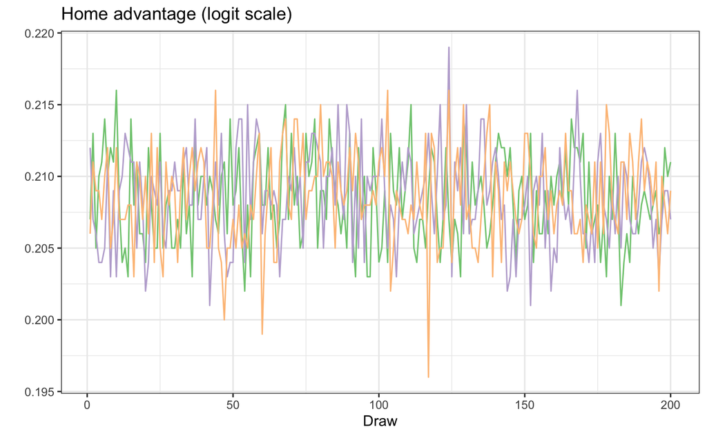

```r
colours <- c("#7fc97f", "#beaed4", "#fdc086")
hfas <- data.frame(round(z$alpha[,,], 3))  %>%
  mutate(draw = 1:n())

hfas %>%
  ggplot(aes(draw, X1)) +
  geom_line(colour = colours[1]) +
  geom_line(data = hfas, aes(draw, X2), colour = colours[2]) +
  geom_line(data = hfas, aes(draw, X3), colour = colours[3]) +
  xlab("Draw") +
  ggtitle("Home advantage (logit scale)") +
  ylab("") +
  theme_bw()
```

The posterior distrbution of $\alpha$ is centered at about 0.208. This suggests that home teams, when playing a similarly talented opponent, have about a $\frac{e^{0.208.}}{1 + e^{0.208}} = 55\%$ chance of winning. For those scoring at home, the NHL has the third best home advantage among the four sports we analyzed.

Next, we examine team strengths.

In the code below, I averaged each team strength over each week of the NHL season, and highlight the Vegas Golden Knights, a team that rose from the bottom of the league towards the top.

As with the home advantage parameter, the y-axis reflects a log-odds scale. In this case, a coefficient of 0.5 reflects that a team has an $\frac{e^{0.5}}{1+e^{0.5}} = 62\%$ chance of beating a league average team at a neutral site.

```r
avgs <- apply(z$theta, c(1,2), mean)
dims <- dim(avgs)
names(dims) <- c("nweeks", "nteams")
df.beta <- data.frame(
    theta = as.vector(avgs),
    week = rep(1:dims["nweeks"]),
    team_id = rep(Teams, each =dims["nweeks"]) )

vegas <- filter(df.beta, team_id == "Vegas Golden Knights")
```

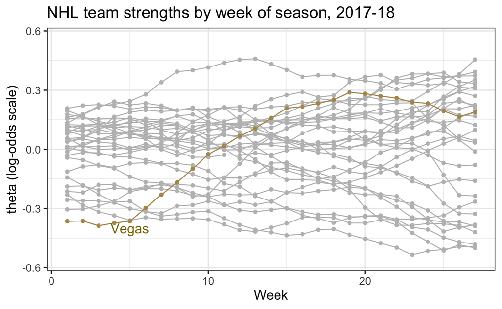

```r
ggplot(df.beta, aes(week, theta, group = team_id)) +
  geom_point(colour = "grey") +
  geom_line(colour = "grey") +
  geom_line(data = vegas, colour = "#b4975a") +
  geom_point(data = vegas, colour = "#b4975a") +
  ggtitle("NHL team strengths by week of season, 2017-18") +
  ylab("theta (log-odds scale)") +
  ylim(c(-0.56, 0.56)) +
  annotate("text",x = 5, y = -0.4, label = "Vegas", colour = "gold4", size = 5) +
  xlab("Week") + theme_bw(14)
```

Vegas had a pretty incredible season.

Of course, it’d be nice to see every team. Next, we use the `teamcolors` package [(link)](https://github.com/beanumber/teamcolors) and a bit of `ggplot2` wizardry to facet each NHL division in order to observe each team.

```r
library(teamcolors)

teamcolors1 <- teamcolors %>%
  filter(league == "nhl") %>%
  rename(team_id = name) %>%
  mutate(
    rand.color = ifelse(primary == "#010101", secondary, primary))

df.beta1 <- df.beta %>%
  left_join(teamcolors1, by = c("team_id" = "team_id"))
```

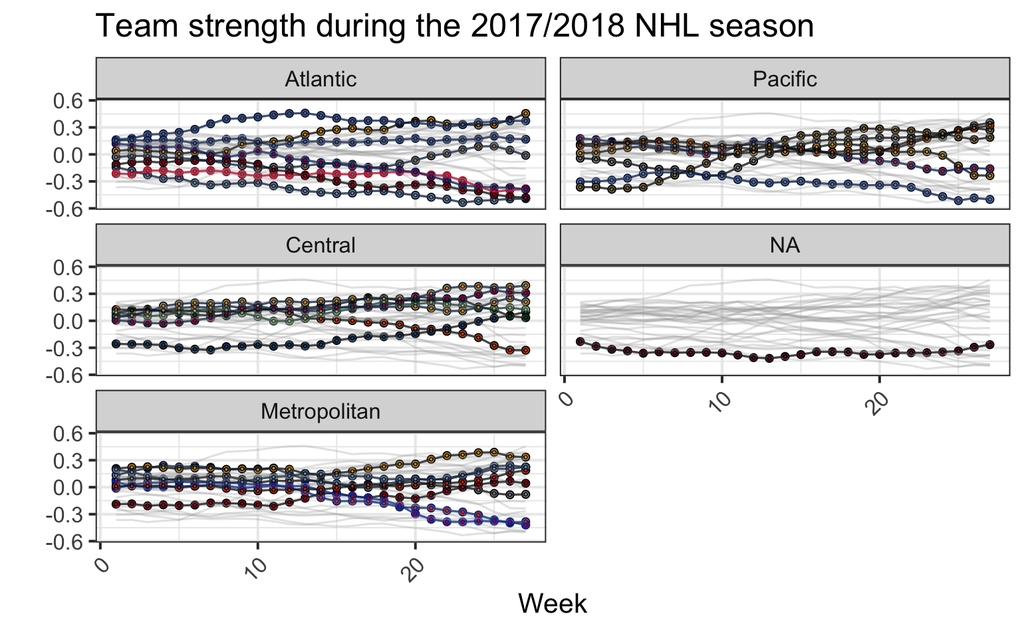

```r
df.overall <- ggplot(data = df.beta1,
       aes(
         x = week, y = theta,
         color = team_id, fill = team_id)) +
  geom_line(alpha = 0.5) +
  geom_point(shape = 21) +
  ylim(c(-0.56, 0.56)) +
  scale_color_manual(name = NULL, values = teamcolors1$primary) +
  scale_fill_manual(name = NULL, values = teamcolors1$secondary) +
  guides(color = FALSE, fill = FALSE) +
  theme_bw(base_size = 14)
df.overall +
  geom_line(data = select(df.beta1, -division), color = "darkgray", alpha = 0.3) +
  geom_line(alpha = 0.5) +
  geom_point(shape = 21, size = 0.5, alpha = 0.8) +
  facet_wrap(~division, ncol = 2, dir = "v") +
  theme(axis.text.x = element_text(angle = 45, hjust = 1)) + ylab("") + xlab("Week") +
  ggtitle("Team strength during the 2017/2018 NHL season")
```

My favorite part about this graph is the distinction between the two Divisions in the Eastern Conference. In the Atlantic Division, Boston, Tampa, and Toronto are three top teams, and apart from the Panthers, the other teams are bottom-dwellers. Meanwhile, nearly every Metropolitan team fits somewhere between the top and bottom of the Atlantic.

Also impressive – check out Colorado’s slow improvement in the Central. The Avalanche started the year as the league’s third worst team (perception-wise), and are now in the playoffs.

## Comparisons among teams

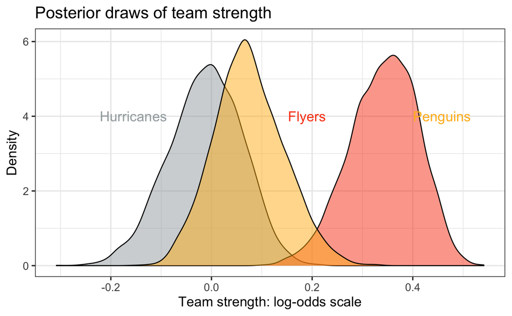

```r
teams <- c("Carolina Hurricanes", "Pittsburgh Penguins", "Philadelphia Flyers")
thetas <- z$theta[20:26, Teams %in% teams, ,]
colors <- teamcolors1$secondary[Teams %in% teams]
team.1 <- data.frame(team_id = teams[1], beta = c(thetas[,1,,]))
team.2 <- data.frame(team_id = teams[2], beta = c(thetas[,2,,]))
team.3 <- data.frame(team_id = teams[3], beta = c(thetas[,3,,]))
df.matchup <- rbind(team.1, team.2, team.3)
lmin <- quantile(df.matchup$beta, 0.01)
umin <- quantile(df.matchup$beta, 0.99)
df.matchup %>% ggplot(aes(beta, fill = team_id, group = team_id)) +
  geom_density(alpha = 0.5) +
  scale_fill_manual(name = NULL, values = colors) +
  annotate("text", x = lmin, y = 4, label = "Hurricanes",colour = colors[1], size = 5) +
  annotate("text", x = .19, y = 4, label = "Flyers", colour = colors[2], size = 5) +
  annotate("text", x = umin, y = 4, label = "Penguins", colour = colors[3], size = 5) +
  ggtitle("Posterior draws of team strength") +
  xlab("Team strength: log-odds scale") + ylab("Density") +
  guides(color = FALSE, fill = FALSE) + theme_bw(14)
```

Above, the Penguins stand out as the best of the three teams. However, although it’s clear the Penguins are better than both the Flyers and the Hurricanes – note the lack of overlap in the density plots – it’s not as clear that the Flyers are better than the Hurricanes.

Using samples from the posterior distribution, we can be a bit more precise: there’s only about a 1 in 2000 chance that the Hurricanes are better than the Penguins, a 1 in 150 chance that the Flyers are better than the Penguins, and a 1 in 5 chance that the Hurricanes are better than the Flyers.

But here’s where the NHL is tricky (e.g, random).

Knowing that the Penguins are better than the Flyers with probability 99.4 percent does not precisely correspond to their chances of actually beating the Flyers when the two teams square off in the 1st round of the 2018 NHL playoffs. In fact, we can use our team strength estimates to sample what a 7-game playoff series could look like, and check how often each team wins. Below, I assume that the Penguins have the home advantage.

```r
set.seed(0)
flyers.strength <- sample(team.2$beta, 7)
penguins.strength <- sample(team.3$beta, 7)
home.advantage <- sample(z$alpha, 7)
logit.games <- penguins.strength - flyers.strength +
  home.advantage*c(1, 1, -1, -1, 1, -1, 1)
prob.games <- exp(logit.games)/(1 + exp(logit.games))
penguin.wins <- rbinom(7, 1, prob = prob.games)
do.penguins.win <- sum(penguin.wins) >= 4
do.penguins.win
```

```
[1] FALSE
```

```r
set.seed(0)
penguins.sim.wins <- 0
for (i in 1:10000){
  flyers.strength <- sample(team.2$beta, 7)
  penguins.strength <- sample(team.3$beta, 7)
  home.advantage <- sample(z$alpha, 7)
  logit.games <- penguins.strength - flyers.strength + home.advantage*c(1, 1, -1, -1, 1, -1, 1)
  prob.games <- exp(logit.games)/(1 + exp(logit.games))
  penguin.wins <- rbinom(7, 1, prob = prob.games)
  do.penguins.win <- sum(penguin.wins) >= 4
  penguins.sim.wins <- penguins.sim.wins + do.penguins.win
}
sum(penguins.sim.wins)/10000
```

```
[1] 0.6624
```

Our numbers suggest that the Penguins would beat the Flyers roughly 2 out of every 3 times they played a 7-game series. Unsurprisingly, this almost exactly matches the probability implied in sportsbook series odds, which currently price the Penguins at -225 and the Flyers at +195.

One last thought: how much is the home advantage worth for Pittsburgh? Tweaking the code above, the Flyers would win about 4% more often if they were the team with an extra home game. In other words, only roughly 1 in 25 series outcomes would change were the Penguins to lose their home advantage to the Flyers. This does not appear to be the answer that my Twitter followers [expected](https://twitter.com/StatsbyLopez/status/983686397818298368), as 1 in 25 was the least likely of four outcomes (10, 15, 20, 25).